# Lab 1

Danielle Caccamo

Due on 02/07 at 11:59 PM

**Instructions:** This lab report needs to be professional. Only report relevant and finalized code. Your writing should be concise and void of spelling errors. Use code chunk options to hide unnecessary messages/warnings. Your report should be reproducible. Reports that involve simulations need to have the random seed specified so that simulation results are reproducible. You are allowed to work on this lab assignment in groups of 2-3. You still need to submit an individual lab report if you do work in a group, and you need to list your collaborators. *{0.5cm}

**Question 1** In lecture it was demonstrated that baseball is a game of offense, pitching, and defense with a regression model that considered expected run differential as a function of explanatory variables OPS, WHIP, and FP. Do the following:

- Fit a similar regression model with runs as the response variable. Report problems with this model. Investigate problematic residuals to discover what went wrong. Fix the problem with this model by adding categorical variable(s) to the list of explanatory variables. Briefly explain what went wrong.

```r
data(Teams)
ds = Teams %>%
  select(R, RA, G, H, BB, HBP, AB, BB, HBP, SF, X2B, X3B, HR, HA, BBA, IPouts, FP, yearID)%>%
  filter(yearID > 1900)%>%
    replace_na(list(HBP = 0, SF = 0)) %>%
    mutate(RD = (R - RA) / G) %>%
    mutate(OBP = (H + BB + HBP)/(AB + BB + HBP + SF)) %>%
    mutate(SLG = (H + X2B + 2*X3B + 3*HR)/AB) %>%
    mutate(OPS = OBP + SLG) %>%
    mutate(WHIP = 3*(HA + BBA)/IPouts)
m = lm(R ~ OPS + WHIP + FP, data = ds)
summary(m)
```

```
##
## Call:
## lm(formula = R ~ OPS + WHIP + FP, data = ds)
##
## Residuals:
##     Min      1Q  Median      3Q     Max
## -564.91  -13.12    9.14   29.35  134.49
##
## Coefficients:
##             Estimate Std. Error t value Pr(>|t|)
## (Intercept)  1081.86     150.95   7.167 9.90e-13 ***
## OPS          1953.78      29.41  66.426  < 2e-16 ***
## WHIP          -49.28      12.06  -4.085 4.53e-05 ***
## FP          -1764.69     160.67 -10.983  < 2e-16 ***
## ---
## Signif. codes:  0 '***' 0.001 '**' 0.01 '*' 0.05 '.' 0.1 ' ' 1
##
## Residual standard error: 66.06 on 2658 degrees of freedom
## Multiple R-squared:  0.6707, Adjusted R-squared:  0.6703
## F-statistic:  1805 on 3 and 2658 DF,  p-value: < 2.2e-16
```

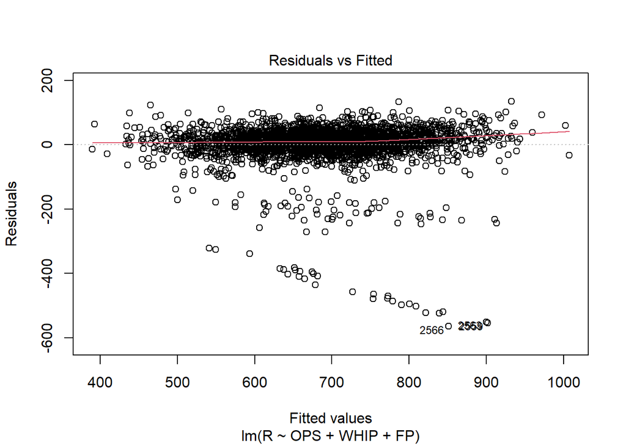

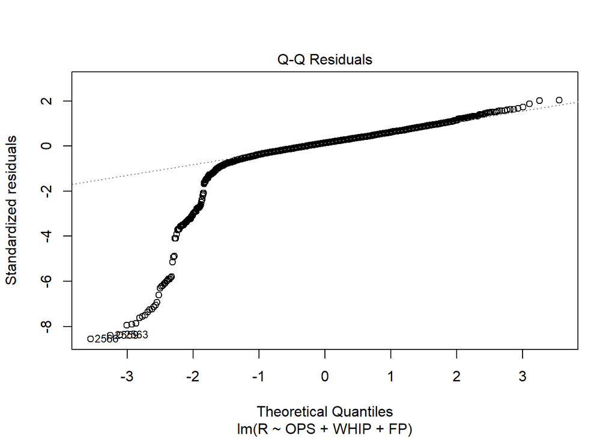

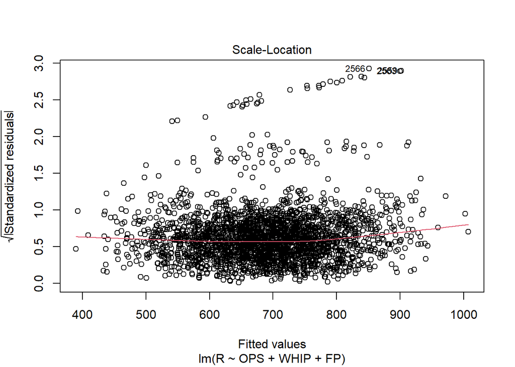

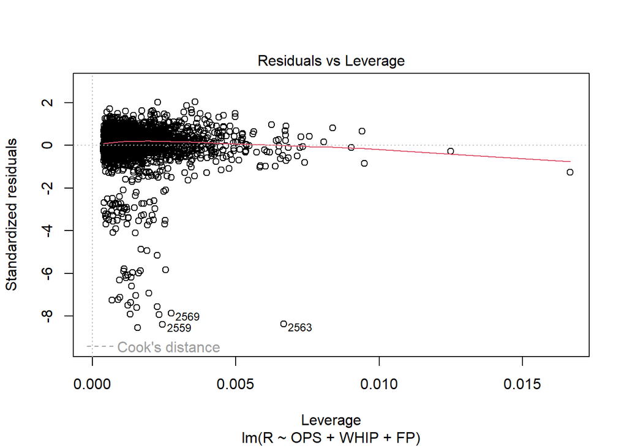

```r
plot(m)
```

```r
residuals_df <- data.frame(yearID = ds$yearID, residuals = residuals(m))
sorted_residuals_df <- residuals_df %>%
  arrange(residuals)
sorted_residuals_df
```

|  | yearID | residuals |
| --- | --- | --- |
| 2566 | 2020 | -564.90595464 |
| 2559 | 2020 | -553.62239232 |
| 2563 | 2020 | -551.27200688 |
| 2552 | 2020 | -524.02391113 |
| 2570 | 2020 | -522.52305732 |
| 2569 | 2020 | -518.95468625 |
| 2545 | 2020 | -502.78221098 |
| 2544 | 2020 | -498.41155431 |
| 2567 | 2020 | -494.55372322 |
| 2572 | 2020 | -485.75031739 |

[output cut: 2652 more lines]

The largest 80 or so residuals are all from the years 2020, 1981, and 1994, so to help improve this model, we could add more explanatory variables and filter the data to exclude those years.

```r
updated_ds <- Teams%>%
  select(R, RA, G, H, BB, HBP, AB, BB, HBP, SF, X2B, X3B, HR, HA, BBA, IPouts, FP, yearID, teamID, franchID)%>%
  filter(yearID > 1900 & yearID < 2020 & yearID != 1981 & yearID != 1994)%>%
    replace_na(list(HBP = 0, SF = 0)) %>%
    mutate(RD = (R - RA) / G) %>%
    mutate(OBP = (H + BB + HBP)/(AB + BB + HBP + SF)) %>%
    mutate(SLG = (H + X2B + 2*X3B + 3*HR)/AB) %>%
    mutate(OPS = OBP + SLG) %>%
    mutate(WHIP = 3*(HA + BBA)/IPouts)
m1 = lm(R ~ OPS + WHIP + FP, data = updated_ds)
summary(m1)
```

```
##
## Call:
## lm(formula = R ~ OPS + WHIP + FP, data = updated_ds)
##
## Residuals:
##     Min      1Q  Median      3Q     Max
## -156.04  -19.36   -0.29   20.17  124.99
##
## Coefficients:
##              Estimate Std. Error t value Pr(>|t|)
## (Intercept)   604.297     77.850   7.762 1.21e-14 ***
## OPS          2006.731     15.297 131.187  < 2e-16 ***
## WHIP          -57.906      6.308  -9.180  < 2e-16 ***
## FP          -1293.003     83.067 -15.566  < 2e-16 ***
## ---
## Signif. codes:  0 '***' 0.001 '**' 0.01 '*' 0.05 '.' 0.1 ' ' 1
##
## Residual standard error: 33.09 on 2484 degrees of freedom
## Multiple R-squared:  0.8991, Adjusted R-squared:  0.899
## F-statistic:  7380 on 3 and 2484 DF,  p-value: < 2.2e-16
```

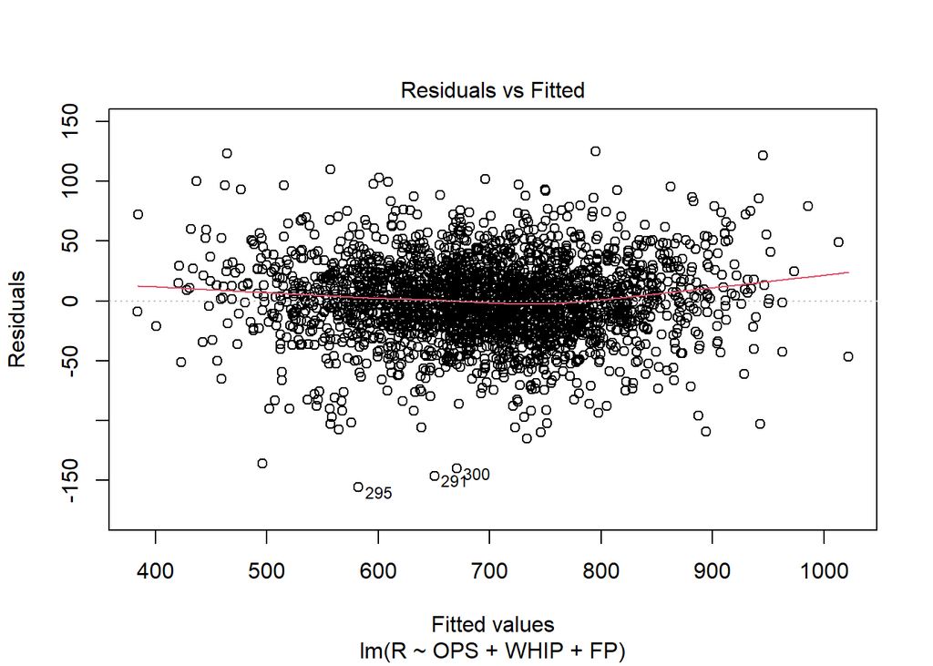

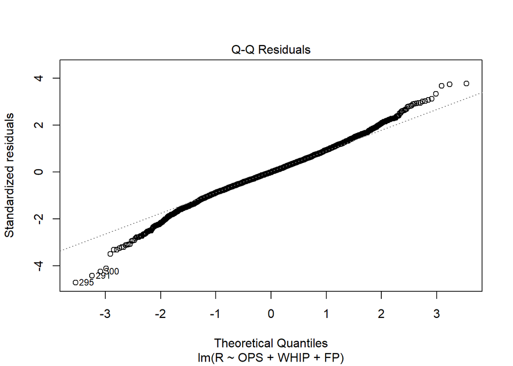

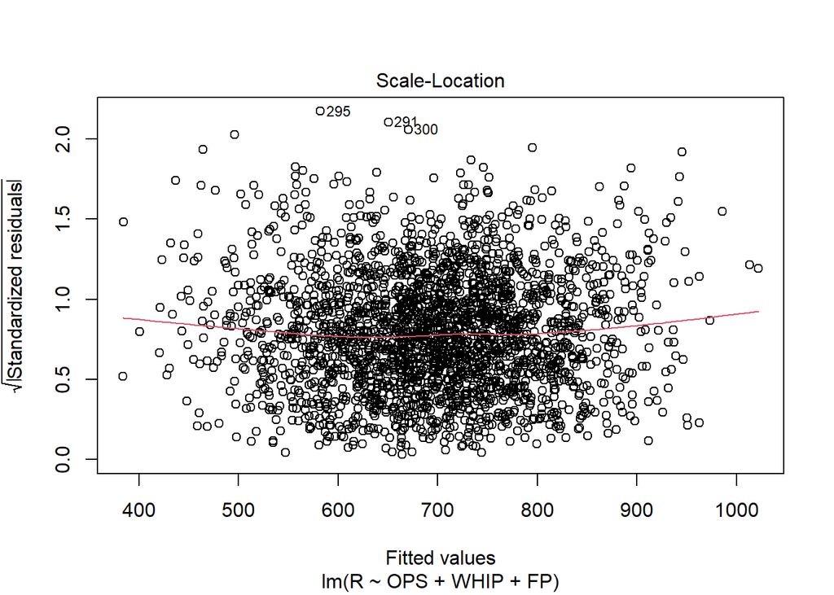

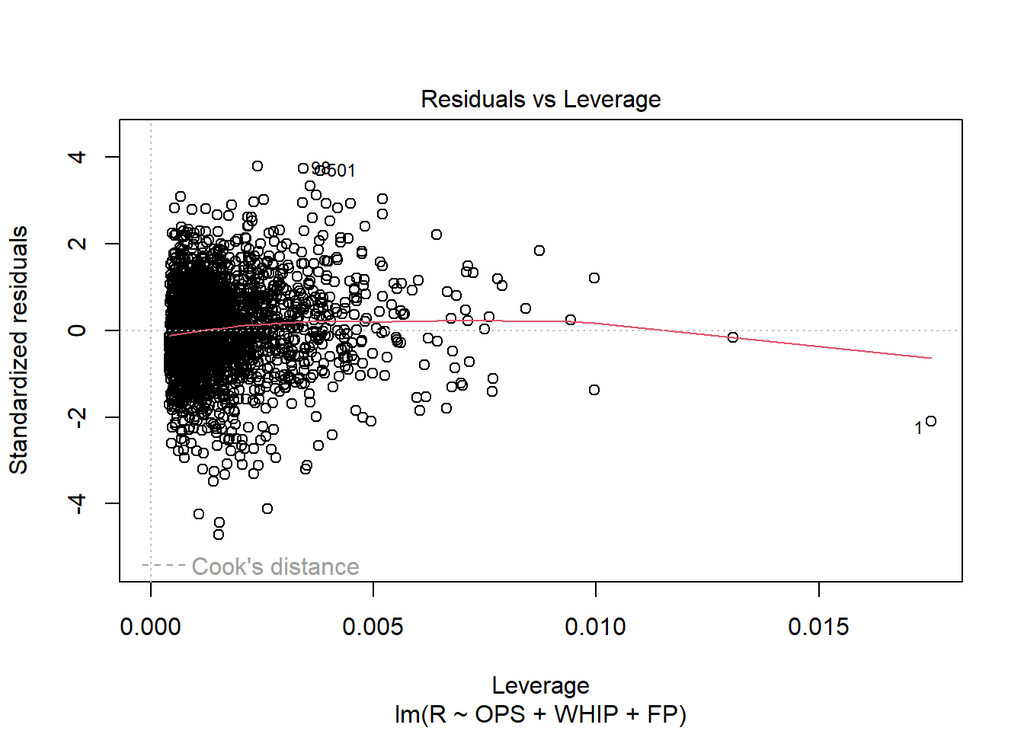

```r
plot(m1)
```

Answer:

```r
rescaleds <- ds %>%
  group_by(yearID)%>%
  filter(yearID > 1900)%>%
  mutate(avgOPS = mean(OPS))%>%
  mutate(avgWHIP = mean(OPS))%>%
  mutate(avgFP = mean(FP))%>%
  mutate(OPSscale = OPS / avgOPS)%>%
  mutate(WHIPscale = avgWHIP / WHIP)%>%
  mutate(FPscale = FP / avgFP)
m2 = lm(RD ~ OPSscale+WHIPscale+FPscale, data = rescaleds)
summary(m2)
```

```
##
## Call:
## lm(formula = RD ~ OPSscale + WHIPscale + FPscale, data = rescaleds)
##
## Residuals:
##      Min       1Q   Median       3Q      Max
## -1.21920 -0.21799 -0.00257  0.21345  1.24898
##
## Coefficients:
##             Estimate Std. Error t value Pr(>|t|)
## (Intercept) -48.9849     1.9291  -25.39   <2e-16 ***
## OPSscale      8.9998     0.1312   68.60   <2e-16 ***
## WHIPscale    10.2958     0.1796   57.32   <2e-16 ***
## FPscale      34.5221     1.9818   17.42   <2e-16 ***
## ---
## Signif. codes:  0 '***' 0.001 '**' 0.01 '*' 0.05 '.' 0.1 ' ' 1
##
## Residual standard error: 0.3316 on 2658 degrees of freedom
## Multiple R-squared:  0.8098, Adjusted R-squared:  0.8096
## F-statistic:  3773 on 3 and 2658 DF,  p-value: < 2.2e-16
```

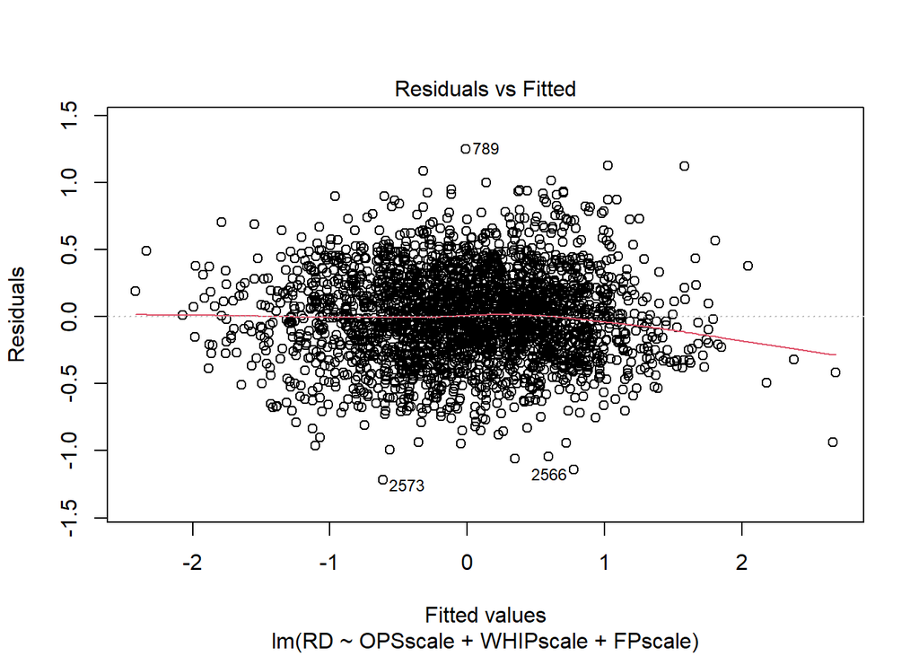

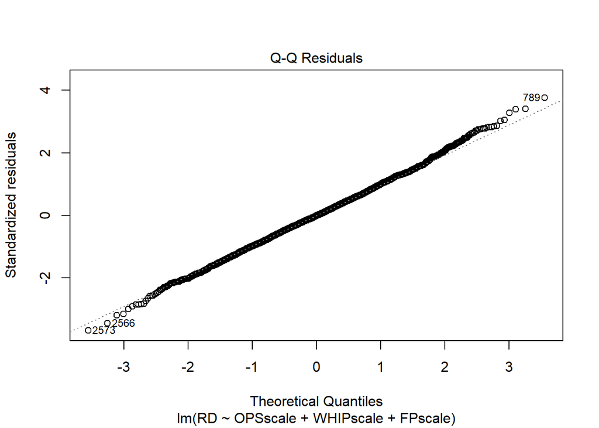

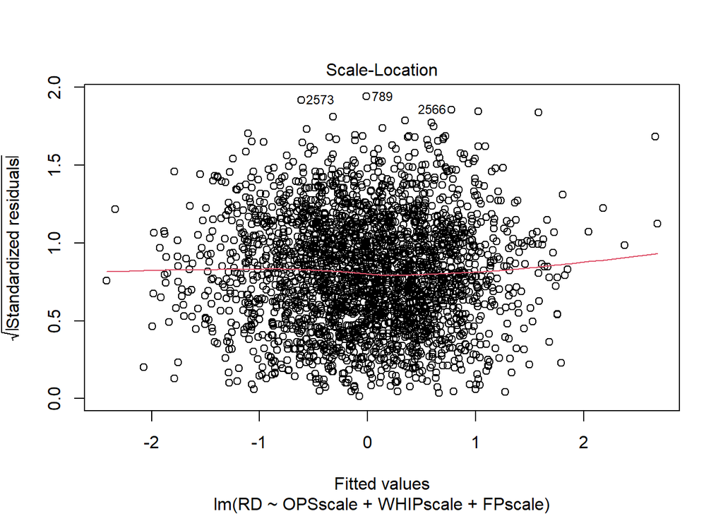

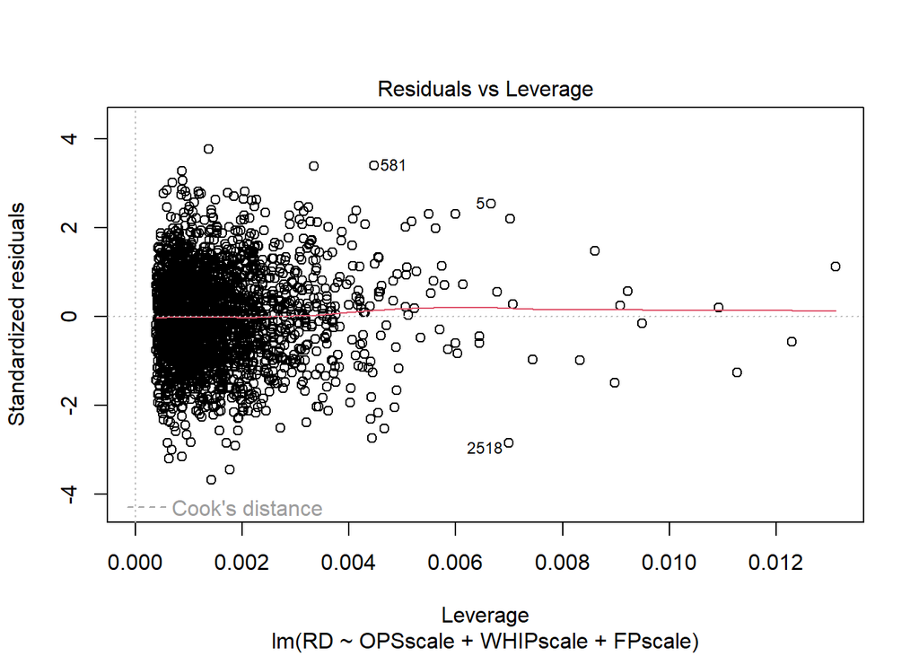

```r
plot(m2)
```

This model performs better because the rescaling of variables accounts for variations for year to year in league performance. It considers how a team compares to its league in a given year whereas the previous model did not do so.

**Question 2** Choose 3 batters and 3 pitchers that have played in at least 10 seasons and do the following:

```r
seasonsb = Batting%>%
  count(playerID)%>%
  filter(n >= 10)%>%
  pull(playerID)
batters = c("dobbsgr01", "chavera01", "browncl01")
#randomly picked three batters
battingds = Batting %>%
  filter(playerID %in% seasonsb, playerID %in% batters)%>%
  select(playerID, yearID, G, AB, R, H, X2B, X3B, HR, RBI, SB, CS, BB, SO, HBP, SF) %>%
  filter(yearID >= 1900) %>%
    replace_na(list(HBP = 0, SF = 0)) %>%
  mutate(OBP = (H + BB + HBP)/(AB + BB + HBP + SF)) %>%
    mutate(SLG = (H + X2B + 2*X3B + 3*HR)/AB) %>%
    mutate(OPS = OBP + SLG) %>%
  mutate(SBscpt = (SB / (SB + CS)))
battingds
```

| playerID | yearID | G | AB | R | H | X2B | X3B | HR | RBI | SB | CS | BB | SO | HBP | SF | OBP | SLG | OPS | SBscpt |
| --- | --- | --- | --- | --- | --- | --- | --- | --- | --- | --- | --- | --- | --- | --- | --- | --- | --- | --- | --- |
| browncl01 | 1928 | 2 | 5 | 1 | 1 | 0 | 0 | 0 | 0 | 0 | 0 | 0 | 1 | 0 | 0 | 0.20000000 | 0.20000000 | 0.4000000 | NaN |
| browncl01 | 1929 | 3 | 7 | 1 | 0 | 0 | 0 | 0 | 0 | 0 | 0 | 0 | 0 | 0 | 0 | 0.00000000 | 0.00000000 | 0.0000000 | NaN |
| browncl01 | 1930 | 35 | 73 | 5 | 18 | 5 | 0 | 0 | 3 | 0 | 0 | 8 | 9 | 0 | 0 | 0.32098765 | 0.31506849 | 0.6360561 | NaN |
| browncl01 | 1931 | 39 | 87 | 8 | 15 | 3 | 0 | 0 | 9 | 0 | 0 | 7 | 6 | 1 | 0 | 0.24210526 | 0.20689655 | 0.4490018 | NaN |
| browncl01 | 1932 | 39 | 100 | 13 | 25 | 4 | 2 | 2 | 18 | 0 | 0 | 8 | 13 | 1 | 0 | 0.31192661 | 0.39000000 | 0.7019266 | NaN |
| browncl01 | 1933 | 34 | 62 | 4 | 9 | 1 | 0 | 0 | 3 | 1 | 0 | 2 | 6 | 0 | 0 | 0.17187500 | 0.16129032 | 0.3331653 | 1.0000000 |
| browncl01 | 1934 | 17 | 17 | 1 | 5 | 1 | 0 | 0 | 1 | 0 | 0 | 2 | 3 | 0 | 0 | 0.36842105 | 0.35294118 | 0.7213622 | NaN |
| browncl01 | 1935 | 23 | 10 | 1 | 2 | 0 | 0 | 0 | 0 | 0 | 0 | 2 | 0 | 0 | 0 | 0.33333333 | 0.20000000 | 0.5333333 | NaN |
| browncl01 | 1936 | 38 | 25 | 5 | 4 | 2 | 0 | 0 | 3 | 0 | 0 | 2 | 1 | 0 | 0 | 0.22222222 | 0.24000000 | 0.4622222 | NaN |
| browncl01 | 1937 | 53 | 18 | 1 | 4 | 0 | 0 | 0 | 3 | 0 | 0 | 5 | 5 | 0 | 0 | 0.39130435 | 0.22222222 | 0.6135266 | NaN |

[output cut: 28 more lines]

```r
seasonsp = Pitching%>%
  count(playerID)%>%
  filter(n >= 10)%>%
  pull(playerID)
pitchers = c("howelja01", "burdele01", "dorisha01")
#randomly picked three pitchers
pitchingds = Pitching %>%
  filter(playerID %in% seasonsp, playerID %in% pitchers)%>%
  select(playerID, yearID, W, L, IPouts, H, ER, HR, BB, HBP, SO, ERA) %>%
  filter(yearID >= 1900) %>%
    replace_na(list(HBP = 0, SF = 0)) %>%
  mutate(SOper9 = (SO / (IPouts/3) * 9))%>%
  mutate(WHIP = (H + BB) / (IPouts / 3))%>%
  mutate(SOperBB = (SO/BB))
pitchingds
```

| playerID | yearID | W | L | IPouts | H | ER | HR | BB | HBP | SO | ERA | SOper9 | WHIP | SOperBB |
| --- | --- | --- | --- | --- | --- | --- | --- | --- | --- | --- | --- | --- | --- | --- |
| burdele01 | 1950 | 0 | 0 | 4 | 3 | 1 | 0 | 0 | 0 | 0 | 6.75 | 0.000000 | 2.2500000 | NaN |
| burdele01 | 1951 | 0 | 0 | 13 | 6 | 3 | 0 | 5 | 1 | 1 | 6.23 | 2.076923 | 2.5384615 | 0.2000000 |
| burdele01 | 1952 | 6 | 11 | 411 | 138 | 55 | 8 | 47 | 2 | 47 | 3.61 | 3.087591 | 1.3503650 | 1.0000000 |
| burdele01 | 1953 | 15 | 5 | 525 | 177 | 63 | 7 | 56 | 5 | 58 | 3.24 | 2.982857 | 1.3314286 | 1.0357143 |
| burdele01 | 1954 | 15 | 14 | 714 | 224 | 73 | 17 | 62 | 4 | 79 | 2.76 | 2.987395 | 1.2016807 | 1.2741935 |
| burdele01 | 1955 | 13 | 8 | 690 | 253 | 103 | 25 | 73 | 6 | 70 | 4.03 | 2.739130 | 1.4173913 | 0.9589041 |
| burdele01 | 1956 | 19 | 10 | 769 | 234 | 77 | 22 | 52 | 3 | 110 | 2.70 | 3.862159 | 1.1157347 | 2.1153846 |
| burdele01 | 1957 | 17 | 9 | 770 | 260 | 106 | 25 | 59 | 2 | 78 | 3.72 | 2.735065 | 1.2428571 | 1.3220339 |
| burdele01 | 1958 | 20 | 10 | 826 | 279 | 89 | 18 | 50 | 5 | 113 | 2.91 | 3.693705 | 1.1949153 | 2.2600000 |
| burdele01 | 1959 | 21 | 15 | 869 | 312 | 131 | 38 | 38 | 1 | 105 | 4.07 | 3.262371 | 1.2082854 | 2.7631579 |

[output cut: 38 more lines]

- Create career stat lines for each of the players that you selected. Be careful about how these statistics are calculated.

```r
career_stat_batting <- battingds %>%
  group_by(playerID)%>%
  summarise(
    G = sum(G, na.rm = TRUE),
    AB = sum(AB, na.rm = TRUE),
    R = sum(R, na.rm = TRUE),
    H = sum(H, na.rm = TRUE),
    X2B = sum(X2B, na.rm = TRUE),
    X3B = sum(X3B, na.rm = TRUE),
    HR = sum(HR, na.rm = TRUE),
    RBI = sum(RBI, na.rm = TRUE),
    SB = sum(SB, na.rm = TRUE),
    CS = sum(CS, na.rm = TRUE),
    SBscpt = sum(SB, na.rm = TRUE)/(sum(SB, na.rm = TRUE)+(sum(CS, na.rm = TRUE))),
    BB = sum(BB, na.rm = TRUE),
    SO = sum(SO, na.rm = TRUE),
    OBP = mean(OBP, na.rm = TRUE),
    SLG = mean(SLG, na.rm = TRUE),
    OPS = mean(OPS, na.rm = TRUE),
    HBP = sum(HBP, na.rm = TRUE),
    SF = sum(SF, na.rm = TRUE)
  )
career_stat_batting
```

| playerID | G | AB | R | H | X2B | X3B | HR | RBI | SB | CS | SBscpt | BB | SO | OBP | SLG | OPS | HBP | SF |
| --- | --- | --- | --- | --- | --- | --- | --- | --- | --- | --- | --- | --- | --- | --- | --- | --- | --- | --- |
| browncl01 | 437 | 457 | 42 | 91 | 17 | 3 | 2 | 46 | 1 | 0 | 1.0000000 | 45 | 55 | 0.2649796 | 0.2537112 | 0.5186908 | 2 | 0 |
| chavera01 | 263 | 680 | 48 | 157 | 27 | 1 | 7 | 65 | 4 | 2 | 0.6666667 | 31 | 115 | 0.2658097 | 0.2853719 | 0.5511816 | 3 | 4 |
| dobbsgr01 | 959 | 2097 | 204 | 548 | 106 | 9 | 46 | 274 | 14 | 6 | 0.7000000 | 132 | 402 | 0.2815311 | 0.3538314 | 0.6353625 | 13 | 26 |

```r
career_stat_pitching <- pitchingds %>%
  group_by(playerID) %>%
  summarise(
    W = sum(W, na.rm = TRUE),
    L = sum(L, na.rm = TRUE),
    IPouts = sum(IPouts, na.rm = TRUE),
    H = sum(H, na.rm = TRUE),
    ER = mean(ER, na.rm = TRUE),
    HR = sum(HR, na.rm = TRUE),
    BB = sum(BB, na.rm = TRUE),
    HBP = sum(HBP, na.rm = TRUE),
    SO = sum(SO, na.rm = TRUE),
    ERA = mean(ERA, na.rm = TRUE),
    WHIP = mean(WHIP, na.rm = TRUE),
    SOper9 = (sum(SO, na.rm = TRUE) / (sum(IPouts, na.rm = TRUE) / 3)) * 9,
    SOperBB = sum(SO, na.rm = TRUE) / sum(BB, na.rm = TRUE)
  )

career_stat_pitching
```

| playerID | W | L | IPouts | H | ER | HR | BB | HBP | SO | ERA | WHIP | SOper9 | SOperBB |
| --- | --- | --- | --- | --- | --- | --- | --- | --- | --- | --- | --- | --- | --- |
| burdele01 | 203 | 144 | 9202 | 3186 | 59.33333 | 289 | 628 | 56 | 1074 | 4.069048 | 1.362556 | 3.151271 | 1.710191 |
| dorisha01 | 45 | 43 | 2503 | 850 | 29.58333 | 57 | 301 | 19 | 332 | 3.641667 | 1.373180 | 3.581302 | 1.102990 |
| howelja01 | 58 | 53 | 2534 | 782 | 20.86667 | 57 | 291 | 19 | 666 | 4.303333 | 1.384853 | 7.096290 | 2.288660 |

- Provide a plot for career trajectories for one batting and one pitching statistic of your choice. These are two separate graphics, one for the batters and one for the pitchers. The graphics that you produce should display the trajectories of the 3 batters and the 3 pitchers. Provide interesting commentary on your graphic.

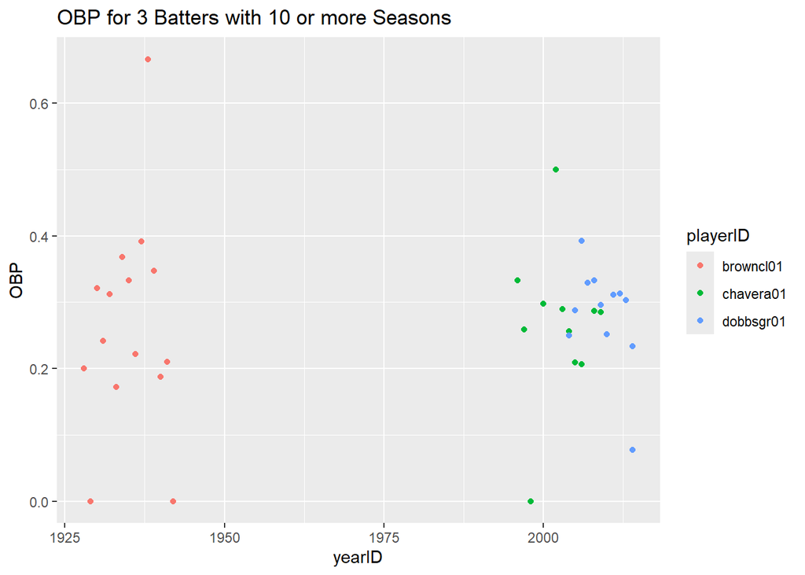

```r
batting_career_stats <- function(batters, battingds) {
  battingds %>%
    filter(playerID %in% batters)%>%
    mutate(OBP = (H+BB+HBP) / (AB+BB+HBP+SF))%>%
    select(playerID, yearID, OBP)
}
batting_stats <- batting_career_stats(batters, battingds)
bs = ggplot(batting_stats, aes(yearID, OBP, color = playerID))+geom_point()
bs + ggtitle("OBP for 3 Batters with 10 or more Seasons")
```

An interesting note regarding the graphic is the amount of variability yet consistency of the players. Browncl01 had on amazing season in 1938, exceeding a 0.6 OBP but has also had two years where it seems as though he didn’t bat, as his OBP was year. Now in the past couple of decades, players seem to be more consistent, as shown with chavera01 and dobbsgr01. A majority of their OBP is between 0.4 and 0.2 with just a few outliers. It is interesting to see how the consistency in players has changed over the years.

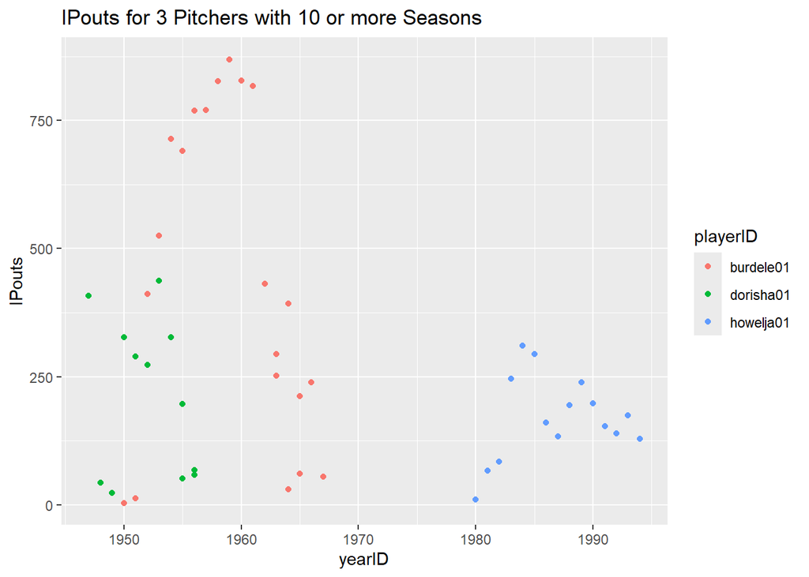

```r
pitching_career_stats <- function(pitchers, pitchingds) {
  pitchingds %>%
    filter(playerID %in% pitchers)%>%
    mutate(IPouts)%>%
    select(playerID, yearID, IPouts)
}
pitching_stats <- pitching_career_stats(pitchers, pitchingds)
ps = ggplot(pitching_stats, aes(yearID, IPouts, color = playerID))+geom_point()
ps + ggtitle("IPouts for 3 Pitchers with 10 or more Seasons")
```

An interesting note is the heavy usage of burdele01 in the late 1950s to 1960s. During this time, he had multiple season with 750+ IPouts which roughly translates to pitching 250+ innings per season. That clearly is something that we don’t see as much today, as shown with howelja01, as it is more common to switch out pitchers multiple times during a game.

**Question 3** Exercise 1.2 in the online version of Analyzing Baseball Data with R. Exercise 2 on page 27 of the textbook.

From the pitching data file from the Lahman database, the following information is collected about [Bob Gibson](https://en.wikipedia.org/w/index.php?search=Bob%20Gibson)’s famous 1968 season.

- Gibson started 34 games for the Cardinals in 1968. What fraction of these games were completed by Gibson?

```r
CG = 28
GS = 34

fraction_completed_BG = CG/GS
fraction_completed_BG
```

```
## [1] 0.8235294
```

- What was Gibson’s ratio of strikeouts to walks this season?

```r
SO = 268
BB = 62

ratio_SO_W_BG = SO/BB
ratio_SO_W_BG
```

```
## [1] 4.322581
```

- One can compute Gibson’s innings pitched by dividing `IPouts` by three. How many innings did Gibson pitch this season?

```r
IPouts = 914

innings_pitched_BG = IPouts/3
innings_pitched_BG
```

```
## [1] 304.6667
```

- A modern measure of pitching effectiveness is WHIP, the average number of hits and walks allowed per inning. What was Gibson’s WHIP for the 1968 season?

```r
WHIP_BG = (198+BB)/(innings_pitched_BG)
WHIP_BG
```

```
## [1] 0.8533917
```

**Question 4** Exercise 1.3 in the online version of Analyzing Baseball Data with R. Exercise 3 on page 27 of the textbook.

[Jim Bunning](https://en.wikipedia.org/w/index.php?search=Jim%20Bunning) pitched a perfect game on Father’s Day on June 21, 1964. Some details about this particular game can be found from the Retrosheet game logs.

- What was the time in hours and minutes of this particular game?

```r
Duration = 139
hours = Duration %/% 60
minutes = Duration %% 60
total_time = cat(hours, "hours and", minutes, "minutes")
```

```
## 2 hours and 19 minutes
```

- Why is the attendance value in this record equal to zero? It is possble that the attendance value is 0 because it may have been an unofficial game or the information was not properly recorded back in 1964, and therefore it is not in the game log from Retrosheet.
- How many extra base hits did the Phillies have in this game? (We know that the Mets had no extra base hits this game.)

```r
HR = 1
D = 2
Tr = 0

EXB_PHI = HR+D+Tr
EXB_PHI
```

```
## [1] 3
```

- What was the Phillies’ on-base percentage in this game?

```r
H = 8
BB = 4
HBP = 0
AB = 32
SF = 0

OBP_PHI = ((H + BB + HBP)/(AB + BB + HBP + SF))
OBP_PHI
```

```
## [1] 0.3333333
```

End of assignment.